# OCTRI-Supported RDW Services & Cohort Discovery Usage Statistics

OCTRI Office of Research Impact

1/30/2018

# Service Level Data

### From FY 2013 to 2017, there were 356 unique OCTRI supported RDW services; there were 484 active OCTRI supported RDW services. Unique services are counted once, during the fiscal year they are initiated. Active services are counted in each year that they are active. If an unique service lasts for more than a year, for example, it was active from FY2014 to 2016, this service will be counted as 3 active services.

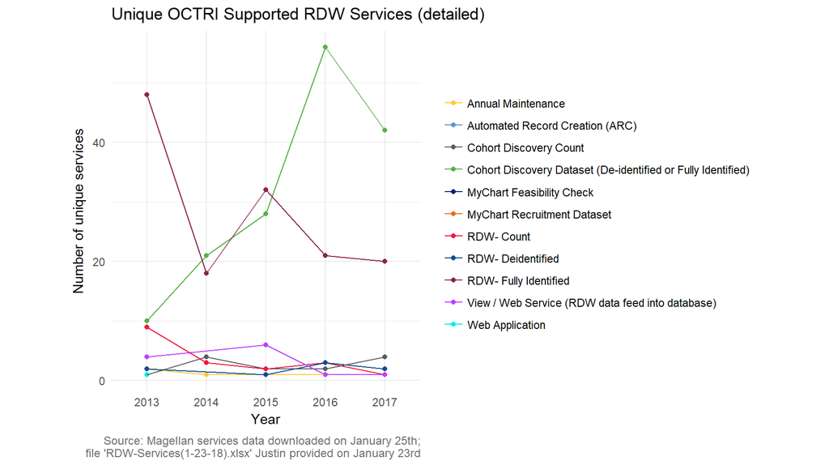

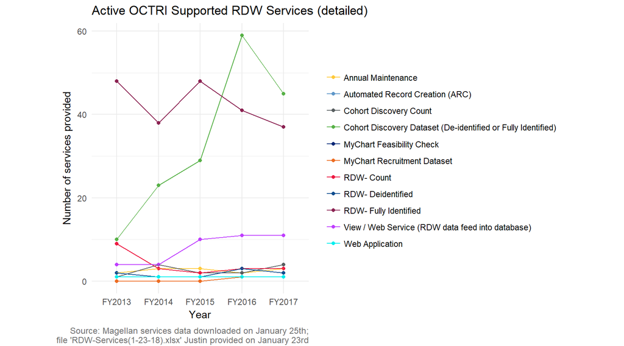

#### Tables of unique RDW services provided by year (detailed)

Source: Magellan services data downloaded on January 25th; file ‘RDW-Services(1-23-18).xlsx’ Justin provided on January 23rd

| year | Annual Maintenance | Automated Record Creation (ARC) | Cohort Discovery Count | Cohort Discovery Dataset (De-identified or Fully Identified) | MyChart Feasibility Check | MyChart Recruitment Dataset | RDW- Count | RDW- Deidentified | RDW- Fully Identified | View / Web Service (RDW data feed into database) | Web Application |
| --- | --- | --- | --- | --- | --- | --- | --- | --- | --- | --- | --- |
| FY2013 | 2 | 0 | 1 | 10 | 0 | 0 | 9 | 2 | 48 | 4 | 1 |
| FY2014 | 1 | 0 | 4 | 21 | 0 | 0 | 3 | 0 | 18 | 0 | 0 |
| FY2015 | 0 | 0 | 2 | 28 | 0 | 0 | 2 | 1 | 32 | 6 | 0 |
| FY2016 | 0 | 1 | 2 | 56 | 1 | 1 | 3 | 3 | 21 | 1 | 0 |
| FY2017 | 1 | 0 | 4 | 42 | 1 | 0 | 1 | 2 | 20 | 1 | 0 |

#### Tables of active RDW services provided by year (detailed)

Source: Magellan services data downloaded on January 25th; file ‘RDW-Services(1-23-18).xlsx’ Justin provided on January 23rd

| year | Annual Maintenance | Automated Record Creation (ARC) | Cohort Discovery Count | Cohort Discovery Dataset (De-identified or Fully Identified) | MyChart Feasibility Check | MyChart Recruitment Dataset | RDW- Count | RDW- Deidentified | RDW- Fully Identified | View / Web Service (RDW data feed into database) | Web Application |
| --- | --- | --- | --- | --- | --- | --- | --- | --- | --- | --- | --- |
| FY2013 | 2 | 0 | 1 | 10 | 0 | 0 | 9 | 2 | 48 | 4 | 1 |
| FY2014 | 3 | 0 | 4 | 23 | 0 | 0 | 3 | 1 | 38 | 4 | 1 |
| FY2015 | 3 | 0 | 2 | 29 | 0 | 0 | 2 | 1 | 48 | 10 | 1 |
| FY2016 | 2 | 1 | 2 | 59 | 1 | 1 | 3 | 3 | 41 | 11 | 1 |
| FY2017 | 3 | 1 | 4 | 45 | 1 | 1 | 3 | 2 | 37 | 11 | 1 |

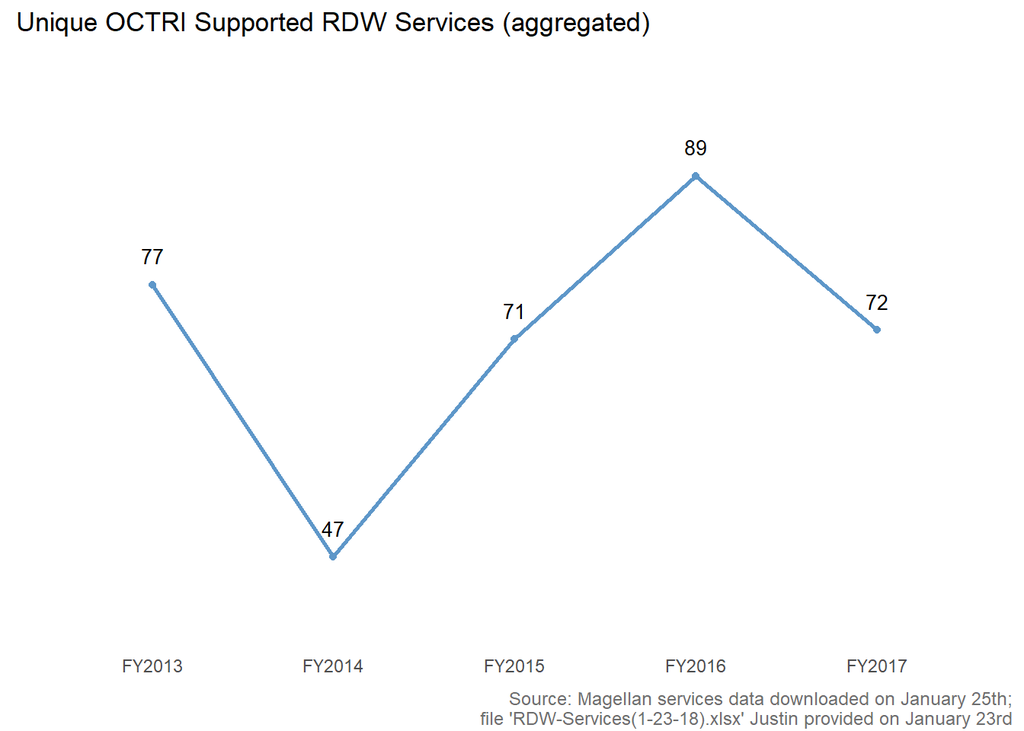

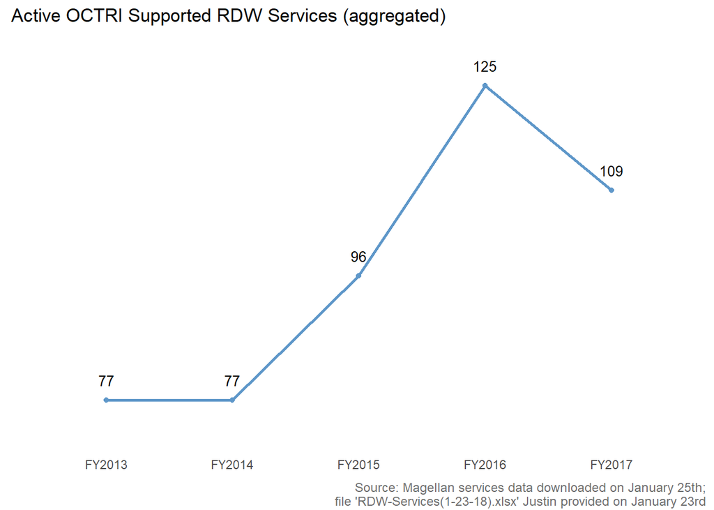

#### Table of unique RDW services provided by year (aggregated)

| year | number |
| --- | --- |
| FY2013 | 77 |
| FY2014 | 47 |
| FY2015 | 71 |
| FY2016 | 89 |
| FY2017 | 72 |
| Total | 356 |

#### Table of active RDW services provided by year (aggregated)

| year | number |
| --- | --- |
| FY2013 | 77 |
| FY2014 | 77 |
| FY2015 | 96 |
| FY2016 | 125 |
| FY2017 | 109 |
| Total | 484 |

# Self-Service Cohort Discovery Statistics

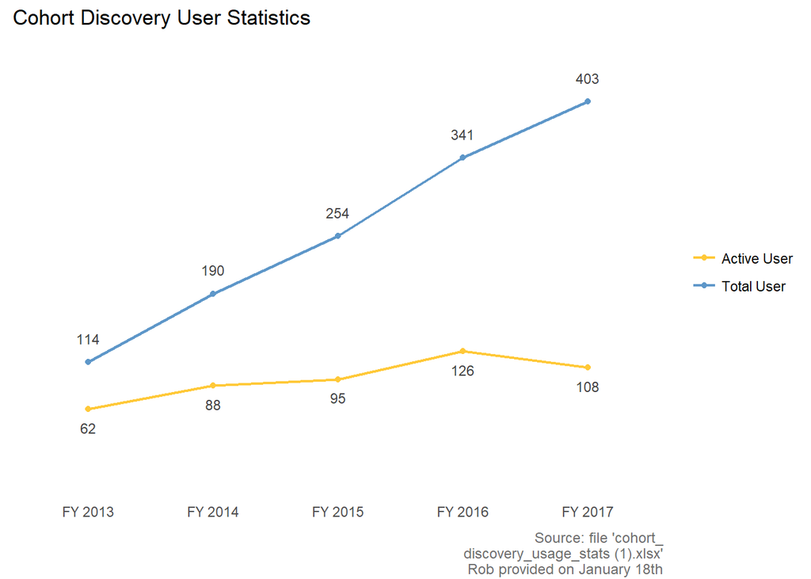

###### *The “Total User” for each year is the total accumulated number of (non-OCTRI) users at the last month of each fiscal year. For example, by June 2017, the total accumulated number of users is 403, which was chosen to be the “Total Number of Users” for FY 2017.

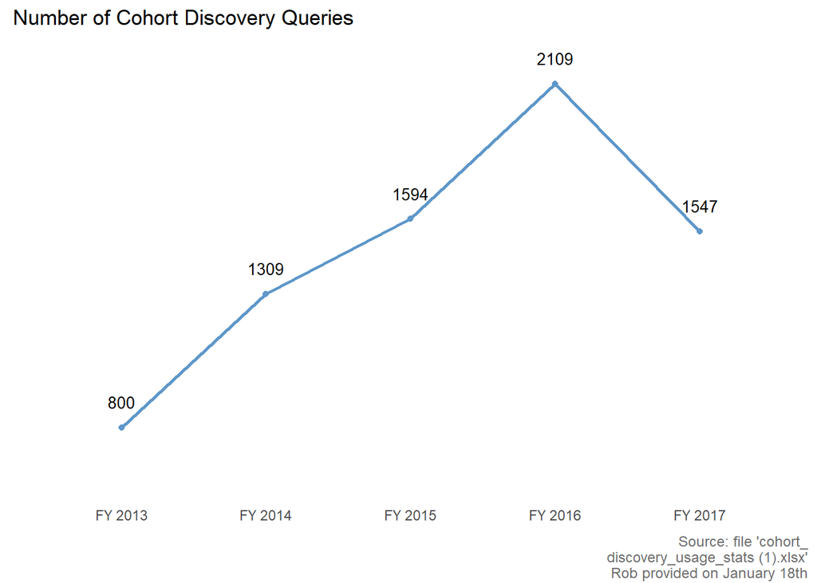

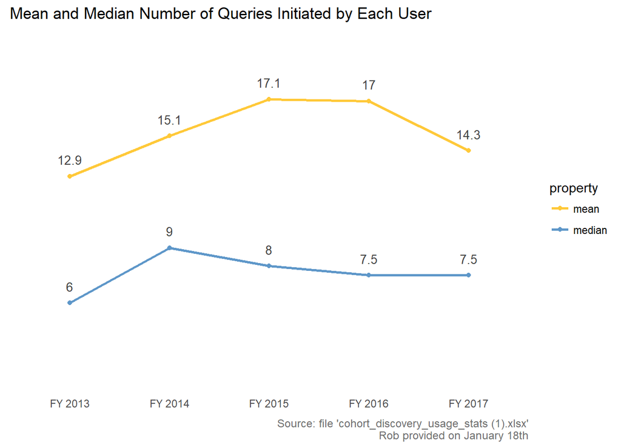

# Department Level Data

#### Departments that utilized RDW by year (by services)

Source: Magellan services data downloaded on January 25th; file ‘RDW-Services(1-23-18).xlsx’ Justin provided on January 23rd; HR data ‘2017-312 HRR - Employee Demographics (ALL).xlsx’ accessed on December 22nd, 2017

| Department | 2013 | 2014 | 2015 | 2016 | 2017 |
| --- | --- | --- | --- | --- | --- |
| Administration (SON) | 1 | 2 | 1 | 0 | 0 |
| Anesthesiology | 4 | 2 | 8 | 4 | 0 |
| Anesthesiology and Perioperative Medicine | 0 | 1 | 0 | 1 | 0 |
| Behavioral Neuroscience | 0 | 0 | 3 | 0 | 2 |
| Biomedical Engineering | 0 | 0 | 0 | 0 | 2 |
| CDRC Eugene | 0 | 0 | 0 | 1 | 0 |
| CHR - Center for Health Research | 1 | 0 | 0 | 0 | 0 |
| Computational Biology | 0 | 0 | 0 | 1 | 1 |
| Dept. of Medical Informatics & Clinical Epidemiology | 0 | 0 | 1 | 0 | 0 |
| Dermatology | 1 | 0 | 0 | 4 | 1 |
| Diabetes | 1 | 0 | 1 | 0 | 0 |
| Diagnostic Radiology | 0 | 0 | 2 | 1 | 1 |
| Emergency Medicine | 3 | 2 | 1 | 1 | 2 |
| Endocrinology | 3 | 1 | 2 | 1 | 0 |
| Family Medicine | 0 | 1 | 0 | 1 | 0 |
| Gastroenterology | 1 | 0 | 0 | 0 | 0 |
| Hematology | 0 | 0 | 0 | 2 | 1 |
| Institute on Development & Disability | 0 | 1 | 0 | 0 | 0 |
| Integrative Biosciences | 1 | 1 | 0 | 1 | 1 |
| Medical Informatics | 0 | 0 | 0 | 1 | 0 |
| Medical Informatics and Clinical Epidemiology (DMICE) | 1 | 0 | 1 | 0 | 0 |
| Medicine | 2 | 1 | 3 | 2 | 1 |
| Medicine (HOSP) | 0 | 0 | 0 | 2 | 0 |
| Medicine/Arthritis & Rheumatic Diseases | 3 | 2 | 1 | 1 | 1 |
| Medicine/Endo/Diab/Clin Nutrition | 0 | 0 | 1 | 1 | 0 |
| Medicine/Gastroenterology & Hepatology | 2 | 3 | 1 | 1 | 2 |
| Medicine/General Internal Medicine | 0 | 1 | 0 | 0 | 0 |
| Medicine/Health Prom & Sports Medicine | 1 | 0 | 0 | 1 | 0 |
| Medicine/Hospital Medicine | 1 | 0 | 0 | 0 | 1 |
| Medicine/Infectious Diseases | 0 | 0 | 1 | 2 | 2 |
| Medicine/Nephrology & Hypertension | 1 | 1 | 3 | 0 | 0 |
| Medicine/Pulmonary & Critical Care Medicine | 2 | 4 | 8 | 4 | 2 |
| Molecular & Medical Genetics | 2 | 0 | 2 | 1 | 0 |
| Molecular Micro/Immunology | 0 | 0 | 0 | 2 | 0 |
| Neurology | 2 | 3 | 7 | 9 | 6 |
| Obstetrics & Gynecology | 3 | 6 | 4 | 6 | 7 |
| OHSU Knight Cancer Institute | 0 | 0 | 1 | 4 | 6 |
| OHSU Knight Cardiovascular Institute | 1 | 0 | 0 | 0 | 0 |
| Ophthalmology | 1 | 2 | 0 | 4 | 3 |
| Oregon Clinical and Translational Research Institute | 0 | 1 | 0 | 0 | 0 |
| Oregon Institute of Occupational Health Sciences | 0 | 0 | 0 | 1 | 0 |
| Orthopaedics and Rehabilitation | 0 | 0 | 0 | 0 | 1 |
| Orthopedics | 1 | 0 | 0 | 0 | 1 |
| Otolaryngology | 0 | 0 | 0 | 1 | 0 |
| Otolaryngology & Head/Neck Surgery | 1 | 2 | 1 | 2 | 1 |
| Pathology | 4 | 1 | 0 | 0 | 1 |
| Pediatric Neurology | 1 | 0 | 0 | 1 | 0 |
| Pediatrics | 12 | 2 | 5 | 6 | 12 |
| Pharmacy | 1 | 0 | 0 | 1 | 3 |
| Pharmacy Practice | 9 | 2 | 0 | 0 | 3 |
| Population-Based Nursing | 1 | 0 | 0 | 1 | 0 |
| Portland Center for the Study of Chronic, Comorbid Mental and Physical Disorders | 0 | 0 | 1 | 0 | 0 |
| Psychiatry | 0 | 1 | 1 | 5 | 1 |
| Psychology | 0 | 0 | 0 | 1 | 1 |
| Public Health and Preventive Medicine | 0 | 1 | 5 | 0 | 1 |
| Research Development and Administration | 0 | 0 | 1 | 0 | 0 |
| Substance Abuse Policy Center, Oregon Health Policy Institute | 0 | 0 | 0 | 1 | 0 |
| Surgery | 8 | 2 | 2 | 8 | 5 |
| Urology | 0 | 0 | 1 | 0 | 0 |
| NA | 1 | 1 | 2 | 2 | 0 |
| Total | 77 | 47 | 71 | 89 | 72 |

#### Units that utilized RDW by year (by services)

| Unit | 2013 | 2014 | 2015 | 2016 | 2017 |
| --- | --- | --- | --- | --- | --- |
| OHSU Hospital | 1 | 0 | 0 | 3 | 3 |
| Oregon Graduate Institute | 0 | 0 | 0 | 0 | 2 |
| Provost | 1 | 0 | 0 | 0 | 0 |
| School of Dentistry | 1 | 1 | 0 | 1 | 1 |
| School of Medicine | 59 | 39 | 59 | 76 | 61 |
| School of Nursing | 2 | 2 | 1 | 1 | 0 |
| School of Public Health | 0 | 1 | 5 | 0 | 1 |
| Vice President for Research | 11 | 3 | 3 | 2 | 3 |
| NA | 2 | 1 | 3 | 6 | 1 |
| Total | 77 | 47 | 71 | 89 | 72 |

#### Departments that utilized RDW (by projects)

Source: Magellan services data downloaded on January 25th; file ‘RDW-Services(1-23-18).xlsx’ Justin provided on January 23rd; HR data ‘2017-312 HRR - Employee Demographics (ALL).xlsx’ accessed on December 22nd, 2017

| Department | n |
| --- | --- |
| Pediatrics | 28 |
| Obstetrics & Gynecology | 22 |
| Neurology | 21 |
| Surgery | 16 |
| Medicine/Pulmonary & Critical Care Medicine | 10 |
| Medicine/Arthritis & Rheumatic Diseases | 9 |
| Medicine/Gastroenterology & Hepatology | 9 |
| Medicine | 8 |
| Ophthalmology | 8 |
| Anesthesiology | 7 |
| Emergency Medicine | 7 |
| Endocrinology | 6 |
| OHSU Knight Cancer Institute | 6 |
| Otolaryngology & Head/Neck Surgery | 6 |
| Psychiatry | 6 |
| NA | 6 |
| Dermatology | 5 |
| Diagnostic Radiology | 5 |
| Pharmacy Practice | 5 |
| Administration (SON) | 4 |
| Behavioral Neuroscience | 4 |
| Molecular & Medical Genetics | 4 |
| Pharmacy | 4 |
| Public Health and Preventive Medicine | 4 |
| Hematology | 3 |
| Medicine/Nephrology & Hypertension | 3 |
| Anesthesiology and Perioperative Medicine | 2 |
| Biomedical Engineering | 2 |
| Diabetes | 2 |
| Family Medicine | 2 |
| Integrative Biosciences | 2 |
| Medical Informatics and Clinical Epidemiology (DMICE) | 2 |
| Medicine (HOSP) | 2 |
| Medicine/Endo/Diab/Clin Nutrition | 2 |
| Medicine/Health Prom & Sports Medicine | 2 |
| Medicine/Hospital Medicine | 2 |
| Medicine/Infectious Diseases | 2 |
| Orthopedics | 2 |
| Pathology | 2 |
| Pediatric Neurology | 2 |
| Population-Based Nursing | 2 |
| CDRC Eugene | 1 |
| CHR - Center for Health Research | 1 |
| Computational Biology | 1 |
| Dept. of Medical Informatics & Clinical Epidemiology | 1 |
| Gastroenterology | 1 |
| Institute on Development & Disability | 1 |
| Medical Informatics | 1 |
| Medicine/General Internal Medicine | 1 |
| Molecular Micro/Immunology | 1 |
| OHSU Knight Cardiovascular Institute | 1 |
| Oregon Clinical and Translational Research Institute | 1 |
| Oregon Institute of Occupational Health Sciences | 1 |
| Orthopaedics and Rehabilitation | 1 |
| Otolaryngology | 1 |
| Portland Center for the Study of Chronic, Comorbid Mental and Physical Disorders | 1 |
| Psychology | 1 |
| Research Development and Administration | 1 |
| Substance Abuse Policy Center, Oregon Health Policy Institute | 1 |
| Urology | 1 |
| Vascular Surgery | 1 |

#### Units that utilized RDW (by projects)

| Unit | n |
| --- | --- |
| School of Medicine | 221 |
| Vice President for Research | 12 |
| NA | 12 |
| OHSU Hospital | 6 |
| School of Nursing | 6 |
| School of Public Health | 4 |
| Oregon Graduate Institute | 2 |
| School of Dentistry | 2 |
| Provost | 1 |

# Award Level Data

### Distribution of award type (by project)

Source: Magellan services data downloaded on January 25th; Magellan OGA data downloaded on December 22nd 2017; file ‘RDW-Services(1-23-18).xlsx’ Justin provided on January 23rd

| funding_award_record_type | n |
| --- | --- |
| Non-OGA Award | 165 |
| OGA Award | 132 |
| No OGA Match in Magellan | 14 |

#### *For records that have âNon-OGA Awardâ as their award record type, their funding statuses are uncertain. Examples of reasons for non-OGA award flags include external awards (not sub-contracts), funding from general ledger (GL) accounts, pending OGA setup, pre-award (application submitted), not submitted, or industry sponsored studies pending funding in OGA.

#### Funding source for “OGA Award” projects

Source: Magellan services data downloaded on January 25th; file ‘RDW-Services(1-23-18).xlsx’ Justin provided on January 23rd; HR data ‘2017-312 HRR - Employee Demographics (ALL).xlsx’ accessed on December 22nd, 2017

| funding_award_record_type | Industry | Internal | NIH | Other | Other Government |
| --- | --- | --- | --- | --- | --- |
| OGA Award | 28 | 1 | 56 | 36 | 11 |